#[본인소속팀]본인이름_클린업_1주차_패키지

## Chapter 1 : Data Preprocessing & EDA

### 문제 1. R과 Python에서 각각 데이터를 불러온 뒤, 데이터의 구조를 파악하세요.

```r
insurance<-read.csv('insurance.csv')
str(insurance)
```

```
## 'data.frame':    1338 obs. of  7 variables:
##  $ age     : int  19 18 28 33 32 31 46 37 37 60 ...
##  $ sex     : chr  "female" "male" "male" "male" ...
##  $ bmi     : num  27.9 33.8 33 22.7 28.9 ...
##  $ children: int  0 1 3 0 0 0 1 3 2 0 ...
##  $ smoker  : chr  "yes" "no" "no" "no" ...
##  $ region  : chr  "southwest" "southeast" "southeast" "northwest" ...
##  $ charges : num  16885 1726 4449 21984 3867 ...
```

```r
head(insurance)
```

```
##   age    sex    bmi children smoker    region   charges
## 1  19 female 27.900        0    yes southwest 16884.924
## 2  18   male 33.770        1     no southeast  1725.552
## 3  28   male 33.000        3     no southeast  4449.462
## 4  33   male 22.705        0     no northwest 21984.471
## 5  32   male 28.880        0     no northwest  3866.855
## 6  31 female 25.740        0     no southeast  3756.622
```

```r
tail(insurance)
```

```
##      age    sex   bmi children smoker    region   charges
## 1333  52 female 44.70        3     no southwest 11411.685
## 1334  50   male 30.97        3     no northwest 10600.548
## 1335  18 female 31.92        0     no northeast  2205.981
## 1336  18 female 36.85        0     no southeast  1629.833
## 1337  21 female 25.80        0     no southwest  2007.945
## 1338  61 female 29.07        0    yes northwest 29141.360
```

###문제2. 데이터에서 각 변수별로 unique한 값이 몇 개씩 존재하는지 파악해주세요.

```r
insurance %>%
  lapply(n_distinct)
```

```
## $age
## [1] 47
##
## $sex
## [1] 2
##
## $bmi
## [1] 548
##
## $children
## [1] 6
##
## $smoker
## [1] 2
##
## $region
## [1] 4
##
## $charges
## [1] 1337
```

###문제3. 문제 1과 문제 2에서 얻어낸 정보들을 바탕으로, 데이터에서 각 변수들이 범주형 변수인지 수치형 변수인지 판단해보고, 그 이유에 대해서 간략하게 서술해주세요.

```r
#수치형 변수
insurance %>%  select_if(is.numeric) %>% names()
```

```
## [1] "age"      "bmi"      "children" "charges"
```

```r
#수치형 변수 numeric으로 변환
insurance <- insurance %>%
  mutate_if(is.numeric,as.numeric)
```

```r
#범주형 변수
insurance %>%  select_if(function(x) !is.numeric(x)) %>% names()
```

```
## [1] "sex"    "smoker" "region"
```

```r
#범주형 변수 factor로 변환
insurance<- insurance %>%
  mutate_if(function(x) !is.numeric(x),as.factor)
```

###문제4. 데이터 내에 결측치가 있는지 간단히 파악해보세요.

```r
#결측치 확인
insurance %>% is.na() %>%  sum()
```

```
## [1] 0
```

```r
#데이터타입 변경 확인
str(insurance)
```

```
## 'data.frame':    1338 obs. of  7 variables:
##  $ age     : num  19 18 28 33 32 31 46 37 37 60 ...
##  $ sex     : Factor w/ 2 levels "female","male": 1 2 2 2 2 1 1 1 2 1 ...
##  $ bmi     : num  27.9 33.8 33 22.7 28.9 ...
##  $ children: num  0 1 3 0 0 0 1 3 2 0 ...
##  $ smoker  : Factor w/ 2 levels "no","yes": 2 1 1 1 1 1 1 1 1 1 ...
##  $ region  : Factor w/ 4 levels "northeast","northwest",..: 4 3 3 2 2 3 3 2 1 2 ...
##  $ charges : num  16885 1726 4449 21984 3867 ...
```

###문제5. 데이터에 있는 ‘age’ 변수를 바탕으로 ’age_group’이라는 범주형 파생변수를 생성해주세요.

```r
#조건에 따라 age_group열 생성성
insurance<-insurance %>%
  mutate(age_group=case_when(
    age>=18 & age <=35 ~ 'young',
    age>=36 & age <55 ~'senior',
    TRUE ~'elder'
  ))
#결과 확인
head(insurance,3)
```

```
##   age    sex   bmi children smoker    region   charges age_group
## 1  19 female 27.90        0    yes southwest 16884.924     young
## 2  18   male 33.77        1     no southeast  1725.552     young
## 3  28   male 33.00        3     no southeast  4449.462     young
```

###문제6. 데이터에서 수치형 변수들만을 사용하여, 수치형 변수들 간의 상관관계를 다음과 같은 상관관계 Plot을 통해 확인해주세요. 그리고 그 결과에 대해서 간단히 해석해주세요.

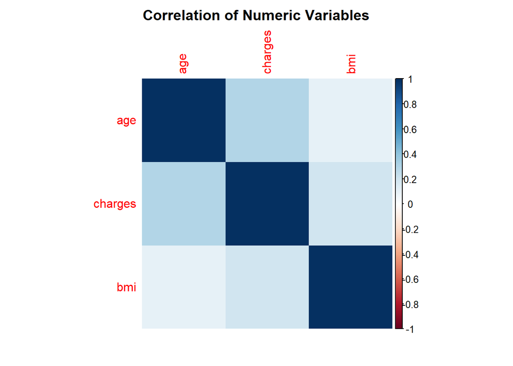

```r
#수치형변수 분리하기기
num_vars <-c('age','bmi','charges')
insurance_num<-insurance[,num_vars]
#수치형변수 상관관계 matrix 만들기기
num_corr<-cor(insurance_num)
#그래프 그리기
corrplot(num_corr,method='shade',order='AOE',main='Correlation of Numeric Variables',mar=c(2,2,2,2))
```

###문제7. 흡연 여부(smoker)에 따른 요금(charges)의 분포를 각각 비흡연자(smoker==no), 흡연자(smoker==yes)로 나누어서 다음과 시각화해주세요. 그 후, 그려진 plot을 통해 알 수 있는 점들을 간략하게 적어주세요.

```r
#색상 설정
my_palette <- brewer.pal(2, "Pastel1")
```

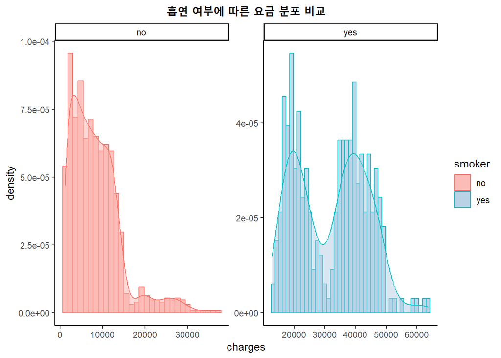

```r
names(my_palette) <- c("no", "yes")
#ggplot으로 그래프 그리기
insurance %>%
  ggplot(aes(x = charges, fill = smoker)) +
  #histplot
  geom_histogram(aes(y=..density..,colour=smoker),binwidth = 1200, alpha = 0.8) +
  #density plot
  geom_density(aes(colour=smoker),alpha=0.5)+
  scale_fill_manual(values = my_palette) +
  #그래프 분리
  facet_wrap(~smoker, ncol = 2, scales = "free",drop=TRUE) +
  #label설정
  labs(x = "charges", y = "density") +
  #테마설정
  theme_classic()+
  #제목설정
  ggtitle('흡연 여부에 따른 요금 분포 비교')+
  theme(plot.title=element_text(hjust=0.5,face='bold'))
```

흡연자에 비해 비흡연자는 보험료가 낮은 쪽에 많이 분포해 있다. 평균적으로 비흡연자가 흡연자보다 보험료를 적게 낸다.

###문제8. 나이 그룹(age_group)에 따른 평균 요금(charge)의 차이를 확인하기 위해 박스 플롯을 그려 다음과 같이 시각화해주세요. 그 후, 그림을 통해 확인할 수 있는 점을 간략하게 적어주세요.

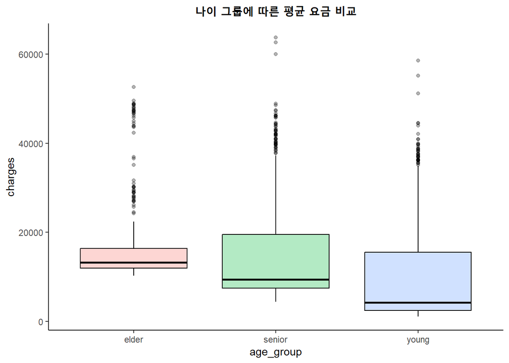

```r
#색상 설정
my_palette <- brewer.pal(3, "Pastel1")
names(my_palette)<-c('elder','young','senior')
#ggplot으로 그래프 그리기
insurance %>% ggplot(aes(x=age_group,y=charges))+
  #boxplot
  geom_boxplot(aes(colour=age_group,fill=age_group),alpha=0.3,color='black')+
  #범례 제거
  guides(fill = FALSE)+
  #테마설정
  theme_classic()+
  #제목설정
  ggtitle("나이 그룹에 따른 평균 요금 비교")+
  theme(plot.title=element_text(hjust=0.5,face='bold'))
```

-ANOVA는 2개 이상의 그룹 간 차이가 있는 지를 평균값 차이를 비교하는 데 사용되는 모델로 그 차이가 유의한지 여부를 검정함. ANOVA를 통해 알아내고자 하는 점은 그룹 간의 차이가 있는지 또 그 정도는 어느 정도인지를 파악하는 것임.

-이 test의 귀무가설은 모든 그룹의 평균이 동일하다는 것이고 대립가설은 적어도 하나의 그룹은 다른 그룹과 동일하지 않다는 것임.

-Z-test 혹은 T-test는 두 그룹 간의 차이만을 비교 할 수 있는데, 그에 따라 그 이상의 그룹들을 비교하기 위해서는 test를 여러번 반복해서 진행해야함. 이 경우, 여러번의 test를 수행하게 됨으로, 검정 결과에 대한 오류가 높아 질 수 있음.

###문제2. ANOVA를 사용하여 나이 그룹(age_group) 간의 평균 요금(charges) 차이가 있는지를 검정해보고, 이를 ANOVA표를 통해 검정 결과를 해석하세요.

```r
#모델 만들기;ANOVA실행하기
charges<-insurance[,'charges']
agegroup<-insurance[,'age_group']
model_aov<-aov(charges~agegroup);anova(model_aov)
```

```
## Analysis of Variance Table
##
## Response: charges
##             Df     Sum Sq    Mean Sq F value    Pr(>F)
## agegroup     2 1.4880e+10 7440230531  54.818 < 2.2e-16 ***
## Residuals 1335 1.8119e+11  135725663
## ---
## Signif. codes:  0 '***' 0.001 '**' 0.01 '*' 0.05 '.' 0.1 ' ' 1
```

1.age_group에 따라 charges에 유의미한 차이가 있음을 확인 할 수 있다. 2.p-value가 매우 작음으로 귀무가설(age_group별 charges에차이가 없다.)를 기각할 수 있다.

###문제3. ANOVA를 사용하여 나이 그룹(age_group) 간의 평균 BMI 값에 차이가 있는지를 검정해보고, 이를 ANOVA표를 통해 검정 결과를 해석하세요.

```r
bmi<-insurance[,'bmi']
model_aov<-aov(bmi~agegroup);anova(model_aov)
```

```
## Analysis of Variance Table
##
## Response: bmi
##             Df Sum Sq Mean Sq F value   Pr(>F)
## agegroup     2    473 236.537  6.4121 0.001693 **
## Residuals 1335  49247  36.889
## ---
## Signif. codes:  0 '***' 0.001 '**' 0.01 '*' 0.05 '.' 0.1 ' ' 1
```

1.age_group에 따라 bmi에 유의미한 차이가 있음을 확인 할 수 있다. 2.p-value가 0.05보다 작음으로 유의수준 alpha=0.05에서서 귀무가설(age_group별 bmi에 차이가 없다.)를 기각할 수 있다.

###문제4. ANOVA를 사용하여 지역(region) 간의 평균 나이(age)의 차이가 있는지를 검정해보고, 이를 ANOVA표를 통해 검정 결과를 해석하세요.

```r
age<-insurance[,'age']
region<-insurance[,'region']
model_aov<-aov(age~region);anova(model_aov)
```

```
## Analysis of Variance Table
##
## Response: age
##             Df Sum Sq Mean Sq F value Pr(>F)
## region       3     47  15.782  0.0798  0.971
## Residuals 1334 263878 197.810
```

1.region에 따라 age에 유의미한 차이가 없음을 확인 할 수 있다. 2.p-value가 매우 높기 때문에 귀무가설(region별 age에 차이가 없다.)를 기각할 수 없다. ###보너스 문제 2. ANOVA의 기본적인 가정은 다음과 같다.

독립성 : 각 그룹이 서로 독립적이다. 등분산성 : 각 그룹 내에서의 분산은 모두 동일하다. 정규성 : 각 그룹 내에서의 관측치는 정규 분포를 따라야 한다.

-독립성 가정은 실험을 통해 증명하기는 일반적으로 어렵지만, 실제 데이터를 수집할 대다수의 경우에 일반적으로 이 가정이 충족된다.

-등분산성 가정은 박스플롯을 통해 대강 확인해 볼 수 있다. 박스 플롯에서 각 그룹의 박스의 크기가 비슷하다면 위 가정을 충족했다고 할 수 있다.

-정규성 가정은 qqplot을 이용할 수 있다. 만약 정규분포를 따른다면 qqplot은 대략적으로 직선에 가깝게 나타난다. ###보너스 문제 3.

```r
smoker<-insurance[,'smoker']
model_aov<-aov(charges~agegroup+smoker+agegroup*smoker);anova(model_aov)
```

```
## Analysis of Variance Table
##
## Response: charges
##                   Df     Sum Sq    Mean Sq   F value Pr(>F)
## agegroup           2 1.4880e+10 7.4402e+09  173.2918 <2e-16 ***
## smoker             1 1.2386e+11 1.2386e+11 2884.8524 <2e-16 ***
## agegroup:smoker    2 1.4444e+08 7.2219e+07    1.6821 0.1864
## Residuals       1332 5.7189e+10 4.2935e+07
## ---
## Signif. codes:  0 '***' 0.001 '**' 0.01 '*' 0.05 '.' 0.1 ' ' 1
```

age_group과 smoker간에 유의 수준 0.05에서 유의한 상호작용 효과가 없다. age_group에 따라 charges에 유의한 차이가 있다. smoker에 따라 charges에 유의한 차이가 있다.